# MTH6139 Time Series

Coursework 1

Sami Rashid

Spring term 2025

[figure not shown]

# **Introduction**

Bitcoin is a **cryptocurrency (virtual money)** designed to act as a form of money and used to make payments outside the control of a group or entity. Therefore, it removes the need for third-party involvement such as banks and is **not controlled by the government**.

Being the **first-ever cryptocurrency**, it is an **extremely volatile financial asset** and has seen large fluctuations in price since its establishment in **2008**.

## **Purpose of the Project**

The purpose of this project is to:

> ✅ **Analyse Bitcoin’s historical price** and how its value has changed over time.  
> ✅ **Use Prophet forecasting** to predict the future prices of Bitcoin.  
> ✅ **Identify seasonality patterns.**

# **Prophet Model**

In this section we identify *trends* and *forecast* the price of Bitcoin using **Prophets** forecasting tool.

The dataset used in this project was obtained from **Kaggle**. It contains the *daily* closing price of bitcoin. You can access the dataset here:  
[Bitcoin Historical Price Dataset (Kaggle)](https://www.kaggle.com/datasets/herculespeters/bitcoin-prices-cleaned-dataset)

## **Load Bitcoin Dataset**

First, we load the dataset using `read_csv`.

```r
#Load dataset
library(readr)
BTC_USD <- read_csv("data/BTC-USD.csv")

#Check dataset is loaded correctly
head(BTC_USD)
```

```
## # A tibble: 6 × 5
##   Date       Price  High   Low  Open
##   <date>     <dbl> <dbl> <dbl> <dbl>
## 1 2014-09-17  457.  468.  452.  466.
## 2 2014-09-18  424.  457.  413.  457.
## 3 2014-09-19  395.  428.  385.  424.
## 4 2014-09-20  409.  423.  390.  395.
## 5 2014-09-21  399.  412.  393.  408.
## 6 2014-09-22  402.  407.  397.  399.
```

## **Formatting the Dataset**

To use the **Prophet** Model we first must:

- Convert the date column to **Prophets** date format (`ds`)
- Set the price as the variable (`y`)

```r
#Convert dataset to Prophet format
library(zoo)
BitcoinData <- data.frame(
  ds = zoo::as.yearmon(BTC_USD$Date),
  y = BTC_USD$Price)

BitcoinData$ds <- as.Date(BitcoinData$ds)
```

## **Visualising Bitcoin Price**

Before we forecast Bitcoins price, it would be a good idea to *plot* a chart of the **historical** price of Bitcoin.

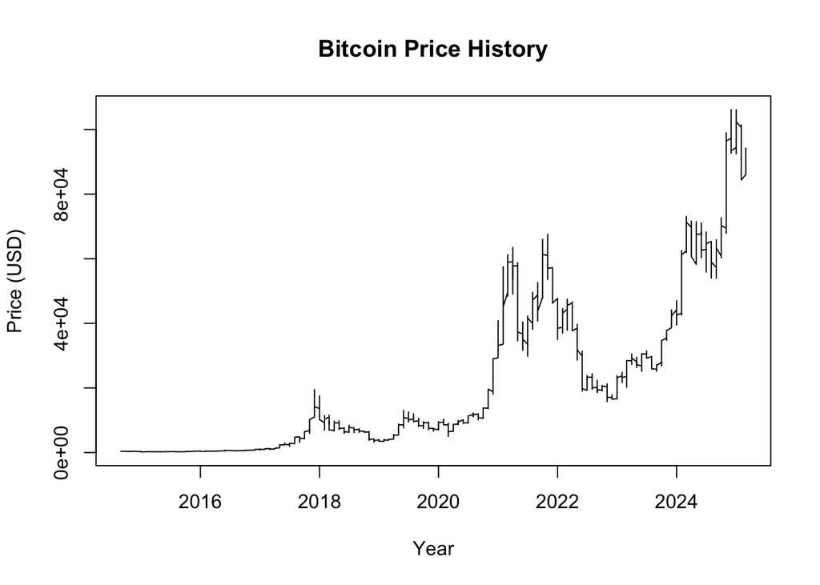

```r
#Plot Bitcoin Price History
plot(BitcoinData$ds, BitcoinData$y,
     type = "l",
     main = "Bitcoin Price History",
     xlab = "Year", ylab = "Price (USD)")
```

## **Implement the Prophet Model**

The **Prophet** model will first identify any **trends or seasonality** from the dataset.

```r
#Check dataset for weekly and yearly seasonality
library(prophet)
BitcoinModel <- prophet(BitcoinData,
                        yearly.seasonality = TRUE,
                        weekly.seasonality = TRUE)

#Forecast next 365 days
FutureBitcoin <- make_future_dataframe(BitcoinModel, periods = 365, freq = "day")
BitcoinForecast <- predict(BitcoinModel, FutureBitcoin)
```

## **Forecasting Bitcoin Price**

We can now `plot` the **forecasted** price of Bitcoin!

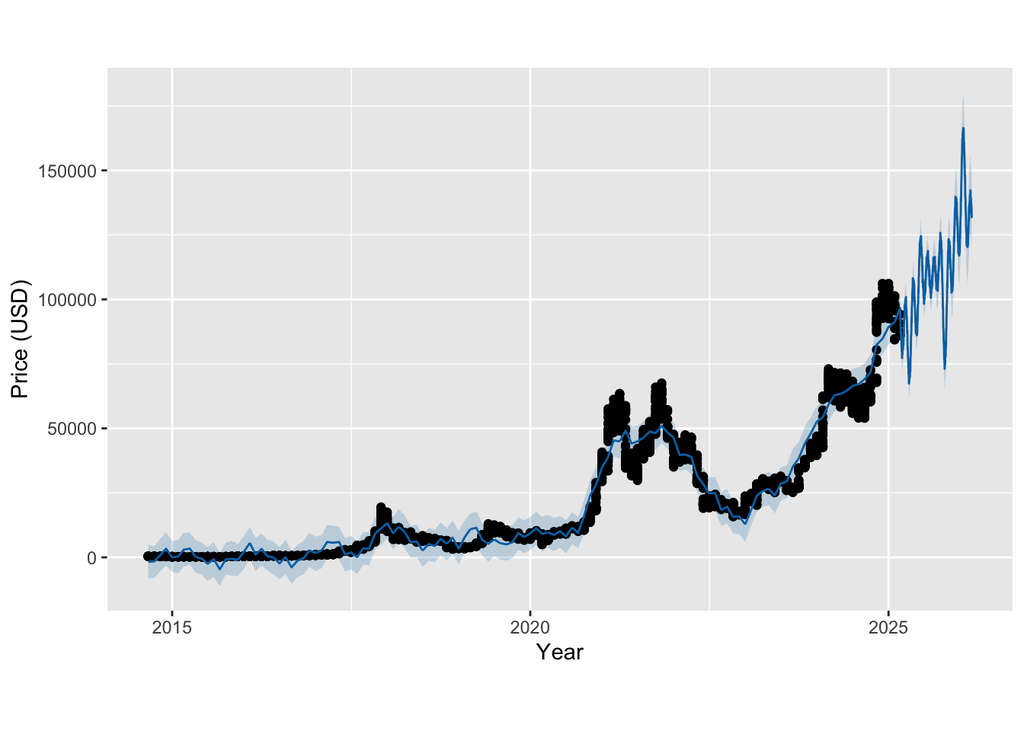

```r
#Plot Bitcoin Forecasted model
plot(BitcoinModel, BitcoinForecast,
     main = "Bitcoin Price Forecast",
     xlab = "Year", ylab = "Price (USD)")
```

The `plot` shows the **historical** Bitcoin Price (black points) with the **forecasted** Bitcoin price (blue line). It also includes levels of **uncertainty** with the blue shaded area.

The forecast suggests a price will **increase** with a continuous **upward trend**

# **Seasonality**

**Prophet** can also give us insights into **weekly** and **yearly** seasonality.

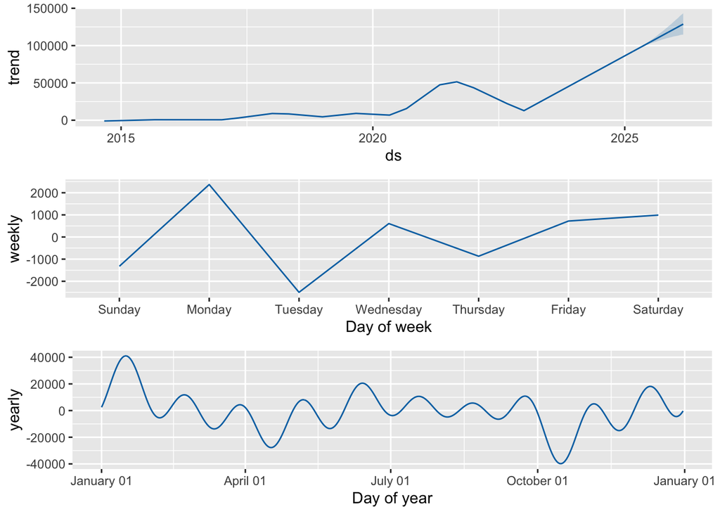

```r
#Plots of Bitcoins seasonality
prophet_plot_components(BitcoinModel, BitcoinForecast)
```

From the *weekly* seasonality we can see that **Monday** has the **highest increase** in price whereas **Tuesday** has the **highest decrease**.

Futhermore, from the *yearly* seasonality we can see a large peak during **January**. We also see big price increases around **June and December**. On the other hand, **April and October** show the largest decreases in price for the year.